# Clase 13: Estadística de Áreas

SP1649 - II 2020

# Modelos autoregresivos espaciales

- Econometría, ecología, epidemeología son las principales áreas de desarrollo.
- Econometría impone su estilo de autocorrelación que Uds conocen de series de tiempo.
- Lo cierto es que hay tantas similitudes con geoestadística como críticas a los modelos de autocorrelación, por lo que este capítulo hay que tomarlo con pinzas.

Iniciamos con el modelo simple:

$Y = \mu + \epsilon$

donde $\mu$ es el vector de medias (que puede modelarse de distintas maneras) y $\epsilon$ es un vector de errores aleatorios, distribuidos como una normal multivariada centrada en cero y con una matriz de variancia-covariancia $\Sigma$. También podemos asumir otras distribuciones para los errores, o utilizar transformaciones para asegurar normalidad.

SAR (Simultaneous Autorregresive) y CAR (Conditionally Autoregressive) son representaciones de los modelos autorregresivos en el espacio, que son muy comunmente utilizados en muchas áreas. En esta clase vamos a describir las características de los dos modelos mediante ejemplos.

Ejemplo: Casos de leucemia en el estado de New York (datos de la clase pasada)

Variable respuesta: $Z =log \frac{1000(Y_i+1)}{n_i}$, donde $Y_i$ son las cuentas en el área $i$, y $n_i$ es el tamaño de la población de la misma área.

Iniciemos con un modelo líneal simple, que asume independencia en los errores, pero utiliza covariables como: PEXPOSURE: distancia inversa a la fuente de TCE (Trichloroethylene) más cercana, PCTAGE65P: proporción de personas con edad de 65 o mayores, y PCTOWNHOME: la proporción de personas que son dueñas de sus casas.

$$Z = \mu + \beta_1 * \text{PEXPOSURE} + \beta_2 * \text{PCTAGE65P} + \beta_3 * \text{PCTOWNHOME} + \epsilon$$

```r
NY8 <- readOGR("data/NY8_utm18.shp", "NY8_utm18")
nylm <- lm(Z~PEXPOSURE+PCTAGE65P+PCTOWNHOME, data=NY8)
summary(nylm)
```

```
##
## Call:
## lm(formula = Z ~ PEXPOSURE + PCTAGE65P + PCTOWNHOME, data = NY8)
##
## Residuals:
##     Min      1Q  Median      3Q     Max
## -1.7417 -0.3957 -0.0326  0.3353  4.1398
##
## Coefficients:
##             Estimate Std. Error t value Pr(>|t|)
## (Intercept) -0.51728    0.15856  -3.262  0.00124 **
## PEXPOSURE    0.04884    0.03506   1.393  0.16480
## PCTAGE65P    3.95089    0.60550   6.525 3.22e-10 ***
## PCTOWNHOME  -0.56004    0.17031  -3.288  0.00114 **
## ---
## Signif. codes:  0 '***' 0.001 '**' 0.01 '*' 0.05 '.' 0.1 ' ' 1
##
## Residual standard error: 0.6571 on 277 degrees of freedom
## Multiple R-squared:  0.1932, Adjusted R-squared:  0.1844
## F-statistic:  22.1 on 3 and 277 DF,  p-value: 7.306e-13
```

```r
NY8$lmresid <- residuals(nylm)
```

En este caso, la exposición a TCE no parece describir bien la respuesta, pero las dos variables censales si. Veamos la distribución de los errores, ¿notan algún rastro de correlación espacial?

```r
TCE <- readOGR("data/TCE.shp", "TCE")
```

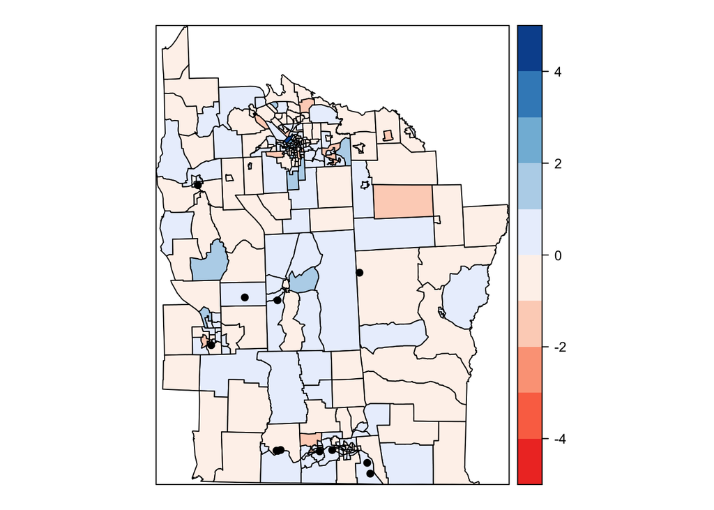

```r
gry <- c(rev(brewer.pal(8, "Reds")[1:6]), brewer.pal(6, "Blues"))
p <- spplot(NY8, c("lmresid"), at=c(seq(-5,5,1)), col.regions=colorRampPalette(gry)(10))
p + layer(panel.points(coordinates(TCE), col="black", pch=19))
```

Hagamos una prueba formal:

```r
NY_nb <- read.gal("data/NY_nb.gal", region.id=row.names(NY8))
NYlistw<-nb2listw(NY_nb, style = "B")
lm.morantest(nylm, NYlistw)
```

```
##
##  Global Moran I for regression residuals
##
## data:
## model: lm(formula = Z ~ PEXPOSURE + PCTAGE65P + PCTOWNHOME, data = NY8)
## weights: NYlistw
##
## Moran I statistic standard deviate = 2.638, p-value = 0.004169
## alternative hypothesis: greater
## sample estimates:
## Observed Moran I      Expectation         Variance
##      0.083090278     -0.009891282      0.001242320
```

El valor p nos indica que hay evidencia para rechazar la hipótesis nula de independencia entre locaciones. Sin embargo, debemos tomar en cuenta lo que comentamos la clase pasada: cuando vamos a aplicaciones prácticas, debemos probar varias opciones de diseño de matriz de vecinos y de covariables para estar seguras de que este resultado no es producto de una mala especificación del modelo.

Entonces, ¿cuál modelo utilizamos?

http://www2.stat.duke.edu/~cr173/Sta444_Sp17/annotated/Lec19_ann.pdf

## SAR (modelos autoregresivos simultáneos)

Recuerde que los residuos en el modelo anterior los denominamos: $\epsilon_i$. Para este modelo, los términos de error se modelan con otra regresión, de la siguiente forma:

$$\epsilon_i = \sum_{j=1}^{m} \beta_{ij}\epsilon_i + \gamma_i.$$

Ahora entonces $\gamma_i$ representa el ruido blanco y los valores de los coeficientes $\beta_{ij}$ se utilizan para representar la dependencia entre las áreas. Aquí es importante recalcar que $\beta_{ii}$ debe fijarse en cero para que cada área no sea modelada con sí misma.

Ahora bien, si utilizamos el error del modelo lineal y lo expresamos como: $\epsilon = B(Y-X^T\beta) + \gamma$, podemos expresar el modelo lineal como:

$$Y = X^T \beta + B(Y- X^T\beta) + \gamma \\
(I - B)(Y-X^T\beta) = \gamma$$

donde B es una matriz que contiene los parámetros $b_{ij}$ que describen la dependencia entre las áreas. Para que el modelo SAR esté bien definido, la matriz (I-B) debe ser no singular.

Bajo este modelo, la respuesta $Y$ se distribuye como una normal multivariante con media $E(Y) = X^T\beta$ y con matriz de covariancia $Var(Y) = (I-B)^{-1}\Sigma_{\gamma} (I - B^T)^{-1}$ y si hacemos $\Sigma_{\gamma} = \sigma^2I$ entonces: $Var(Y) = \sigma^2 (I-B)^{-1}(I - B^T)^{-1}$.

Otra parametrización consiste en escribir el modelo con $B = \lambda W$ donde $\lambda$ es el parámetro de autocorrelación espacial y W es una matriz que representa la dependencia espacial (en muchos casos se asume como simétrica). En este caso podemos reescribir la variancia como:

$$Var(Y) = \sigma^2 (I - \lambda W)^{-1}(I - \lambda W)^{-1}$$

Para estimar estos modelos, podemos recurrir a maximizar la verosimilitud (utilizando estadística clásica). Esto puede hacerse con el paquete spdep, que incluye la función spautolm, que recibe a W como un un objeto listw (que vimos en la clase pasada).

El siguiente código ofrece un ejemplo de cómo ajustar un SAR:

```r
NYlistwW <- nb2listw(NY_nb, style = "W")
# dos maneras de estimar lambda SIN el modelo:
aple(residuals(nylm), listw=NYlistwW)
```

```
## [1] 0.2051536
```

```r
spautolm(Z~PEXPOSURE+PCTAGE65P+PCTOWNHOME, data=NY8, listw=NYlistwW)$lambda
```

```
##    lambda
## 0.2169261
```

```r
## ahora con el modelo:
nysar<-spautolm(Z~PEXPOSURE+PCTAGE65P+PCTOWNHOME, data=NY8, listw=NYlistw)
summary(nysar)
```

```
##
## Call: spautolm(formula = Z ~ PEXPOSURE + PCTAGE65P + PCTOWNHOME, data = NY8,
##     listw = NYlistw)
##
## Residuals:
##      Min       1Q   Median       3Q      Max
## -1.56754 -0.38239 -0.02643  0.33109  4.01219
##
## Coefficients:
##              Estimate Std. Error z value  Pr(>|z|)
## (Intercept) -0.618193   0.176784 -3.4969 0.0004707
## PEXPOSURE    0.071014   0.042051  1.6888 0.0912635
## PCTAGE65P    3.754200   0.624722  6.0094 1.862e-09
## PCTOWNHOME  -0.419890   0.191329 -2.1946 0.0281930
##
## Lambda: 0.040487 LR test value: 5.2438 p-value: 0.022026
## Numerical Hessian standard error of lambda: 0.017199
##
## Log likelihood: -276.1069
## ML residual variance (sigma squared): 0.41388, (sigma: 0.64333)
## Number of observations: 281
## Number of parameters estimated: 6
## AIC: 564.21
```

```r
nylam1 <- c(nysar$lambda)
nylam2 <- c(LR1.spautolm(nysar)$p.value)
```

Test de verosimilitud: $H_0:\lambda=0$, en este caso rechazo $H_0$ aun cuando incluyo las covariables. Noten cómo los valores p de cada covariable cambiaron ahora que tomamos en cuenta la autocorrelación espacial.

Para verificar el aporte de los componentes no espaciales y espaciales en los valores ajustados, la función spautolm tiene dos valores muy útiles: signal_trend ($X^T\hat{\beta}$)y signal_stochastic ($\hat{B}(Y-X^T\hat{\beta})$).

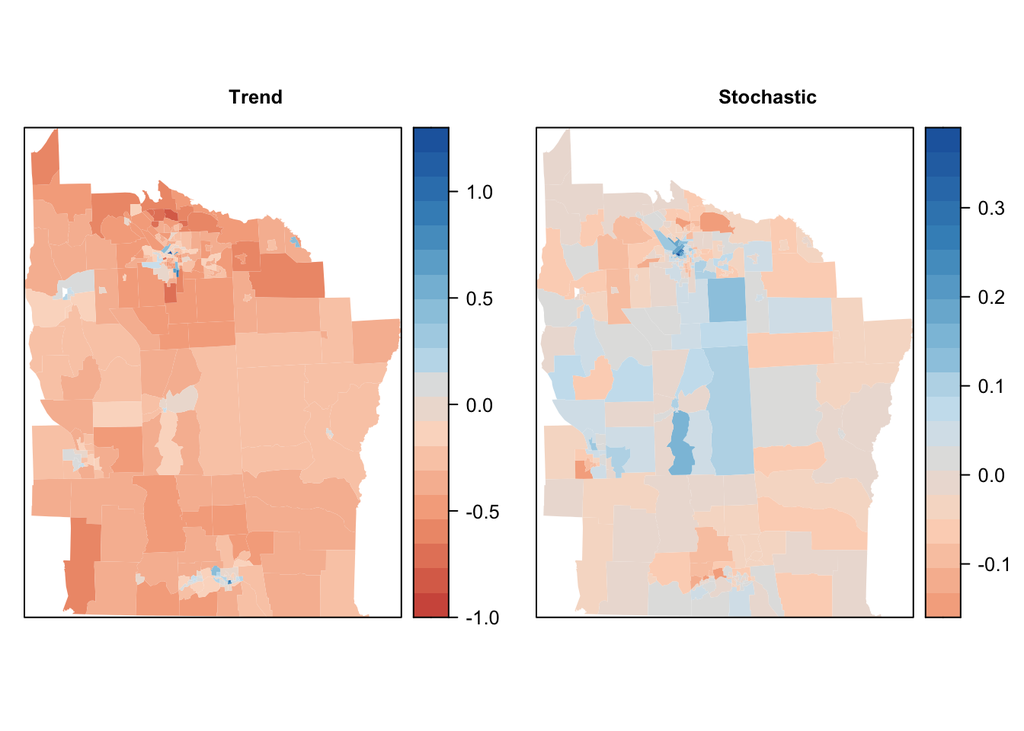

```r
NY8$sar_trend <- nysar$fit$signal_trend
NY8$sar_stochastic <- nysar$fit$signal_stochastic
rds <- colorRampPalette(brewer.pal(8, "RdBu"))
tr_at <- seq(-1, 1.3, length.out=21)
tr_rds <- rds(sum(tr_at >= 0)*2)[-(1:(sum(tr_at >= 0)-sum(tr_at < 0)))]
tr_pl <- spplot(NY8, c("sar_trend"), at=tr_at, col="transparent", col.regions=tr_rds, main=list(label="Trend", cex=0.8))
st_at <- seq(-0.16, 0.39, length.out=21)
st_rds <- rds(sum(st_at >= 0)*2)[-(1:(sum(st_at >= 0)-sum(st_at < 0)))]
st_pl <- spplot(NY8, c("sar_stochastic"), at=st_at, col="transparent", col.regions=st_rds, main=list(label="Stochastic", cex=0.8))
plot(tr_pl, split=c(1,1,2,1), more=TRUE)
plot(st_pl, split=c(2,1,2,1), more=FALSE)
```

Un detalle importante: podemos corregir el modelo tomando en cuenta los tamaños de la población de cada área. Para ello, podemos utilizar los pesos en la función lm:

```r
nylmw <- lm(Z~PEXPOSURE+PCTAGE65P+PCTOWNHOME, data=NY8, weights=POP8)
summary(nylmw)
```

```
##
## Call:
## lm(formula = Z ~ PEXPOSURE + PCTAGE65P + PCTOWNHOME, data = NY8,
##     weights = POP8)
##
## Weighted Residuals:
##      Min       1Q   Median       3Q      Max
## -129.067  -14.714    5.817   25.624   70.723
##
## Coefficients:
##             Estimate Std. Error t value Pr(>|t|)
## (Intercept) -0.77837    0.14116  -5.514 8.03e-08 ***
## PEXPOSURE    0.07626    0.02731   2.792  0.00560 **
## PCTAGE65P    3.85656    0.57126   6.751 8.60e-11 ***
## PCTOWNHOME  -0.39869    0.15305  -2.605  0.00968 **
## ---
## Signif. codes:  0 '***' 0.001 '**' 0.01 '*' 0.05 '.' 0.1 ' ' 1
##
## Residual standard error: 33.5 on 277 degrees of freedom
## Multiple R-squared:  0.1977, Adjusted R-squared:  0.189
## F-statistic: 22.75 on 3 and 277 DF,  p-value: 3.382e-13
```

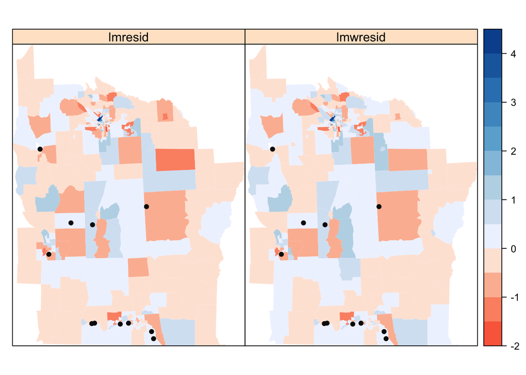

```r
NY8$lmwresid <- residuals(nylmw)
gry <- c(rev(brewer.pal(6, "Reds")[1:4]), colorRampPalette(brewer.pal(5, "Blues"))(9))
TCEpts <- list("sp.points", TCE, pch=16, col="grey5")
spplot(NY8, c("lmresid", "lmwresid"), sp.layout=list(TCEpts), col.regions=gry, col="transparent", lwd=0.5, at=seq(-2,4.5,0.5))
```

Los residuos cambiarán en aquellas áreas en donde la población es mucho mayor o mucho menor que la media de población para todas las áreas.

Ahora repitamos el mismo ejercicio de antes con los residuales del modelo corregido con los pesos de tamaño de población.

```r
lm.morantest(nylmw, NYlistw)
```

```
##
##  Global Moran I for regression residuals
##
## data:
## model: lm(formula = Z ~ PEXPOSURE + PCTAGE65P + PCTOWNHOME, data = NY8,
## weights = POP8)
## weights: NYlistw
##
## Moran I statistic standard deviate = 0.4773, p-value = 0.3166
## alternative hypothesis: greater
## sample estimates:
## Observed Moran I      Expectation         Variance
##      0.007533246     -0.009309771      0.001245248
```

El resultado sugiere que el patrón espacial que detectamos antes puede darse debido a la heteroscedasticidad (diferencias en los tamaños de población de cada área) y no a un patrón espacial. Veamos qué pasa con el modelo SAR:

```r
nysarw<-spautolm(Z~PEXPOSURE+PCTAGE65P+PCTOWNHOME , data=NY8, listw=NYlistw, weights=POP8)
summary(nysarw)
```

```
##
## Call: spautolm(formula = Z ~ PEXPOSURE + PCTAGE65P + PCTOWNHOME, data = NY8,
##     listw = NYlistw, weights = POP8)
##
## Residuals:
##      Min       1Q   Median       3Q      Max
## -1.48488 -0.26823  0.09489  0.46552  4.28343
##
## Coefficients:
##              Estimate Std. Error z value  Pr(>|z|)
## (Intercept) -0.797063   0.144054 -5.5331 3.146e-08
## PEXPOSURE    0.080545   0.028334  2.8428  0.004473
## PCTAGE65P    3.816731   0.576037  6.6258 3.453e-11
## PCTOWNHOME  -0.380778   0.156507 -2.4330  0.014975
##
## Lambda: 0.0095636 LR test value: 0.32665 p-value: 0.56764
## Numerical Hessian standard error of lambda: 0.016466
##
## Log likelihood: -251.6017
## ML residual variance (sigma squared): 1104.1, (sigma: 33.229)
## Number of observations: 281
## Number of parameters estimated: 6
## AIC: 515.2
```

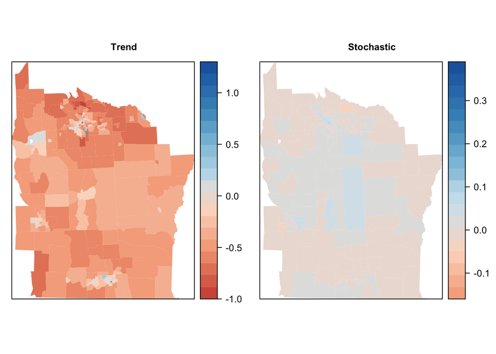

```r
NY8$sarw_trend <- nysarw$fit$signal_trend
NY8$sarw_stochastic <- nysarw$fit$signal_stochastic
tr_pl <- spplot(NY8, c("sarw_trend"), at=tr_at, col="transparent", col.regions=tr_rds, main=list(label="Trend", cex=0.8))
st_pl <- spplot(NY8, c("sarw_stochastic"), at=st_at, col="transparent", col.regions=st_rds, main=list(label="Stochastic", cex=0.8))
plot(tr_pl, split=c(1,1,2,1), more=TRUE)
plot(st_pl, split=c(2,1,2,1), more=FALSE)
```

En este caso no tenemos evidencia de correlación espacial, sin embargo note cómo todos los valores p de las covariables han cambiado. Esto sugiere que la autocorrelación espacial tenía que ver con la población por área y no con la variable de interés.

Finalmente, para comparar todos los modelos podemos usar el AIC:

- nysar: AIC: 564.21
- nysarw: AIC: 515.2

## CAR (modelos autoregresivos condicionales)

La especificación del modelo CAR se basa en el modelo condicional. De ahí que sea tan utilizado en modelos Bayesianos: con paquetes como BUGS y JAGS, las estimaciones siempre se dan usando GIBBS, por lo tanto la especificación condicional tiene mucho sentido en este caso.

En este caso, la distribución de $\epsilon_i | \epsilon_{i-1}$ es especificada como:

$$\epsilon_i | \epsilon_{-1} \sim N\left( \sum_{c_{ij} \neq 0 }c_{ij}\epsilon_j, m_{ii}\right).$$

Donde $c_{ij}$ son los parámetros de dependencia de la matriz $C$ similares a $b_{ij}$ y $m_{ii}$ son los elementos de la diagonal de una matriz de covariancia (variancia). Ahora, en lugar de escribir todo el vector de $\epsilon_{-i}$, podemos definir solo los vecinos del área $i$. Entonces, una manera muy simple de escribir la distribución condicional es:

$$\epsilon_i | \epsilon_{i-1} \sim N\left( \sum_{j \sim i}\frac{c_{ij}\epsilon_j}{\sum_{j\sim i} c_{ij}}, \frac{\sigma^2_{\epsilon_i}}{\sum_{j\sim i} c_{ij}}\right).$$

Sin embargo, al especificar las distribuciones del error condicionales, no estamos asegurando que la distribución conjunta exista. Para ello, debemos imponer ciertas restricciones.

Para tener una distribución propia, (I - C) debe tener valores propios positivos, y $\Sigma = \sigma^2(I-C)^{-1}M$ debe ser simétrica, lo que implica que:

$$\frac{c_{ij}}{m_{ii}}=\frac{c_{ji}}{m_{jj}}, \forall i, j.$$

En este caso, si $C = \lambda W$ entonces $\rho$ puede tener las mismas restricciones que tiene en el modelo SAR: si $1 / \eta_{[1]} < \lambda < 1/\eta_{[N]}$, donde $\eta_{[1]}$ es el valor propio menor de W y _{[N]} es el valor propio mayor de W, entonces los valores propios de $(1-\lambda W)$ tendrá valores propios positivos.

Más detalles aquí: https://esajournals.onlinelibrary.wiley.com/doi/full/10.1002/ecm.1283

Para efectos prácticos, podemos usar la función spautolm de nuevo, especificando la familia como CAR (SAR es el default).

```r
nycar<-spautolm(Z~PEXPOSURE+PCTAGE65P+PCTOWNHOME , data=NY8, family="CAR",
                listw=NYlistw)
summary(nycar)
```

```
##
## Call: spautolm(formula = Z ~ PEXPOSURE + PCTAGE65P + PCTOWNHOME, data = NY8,
##     listw = NYlistw, family = "CAR")
##
## Residuals:
##       Min        1Q    Median        3Q       Max
## -1.539732 -0.384311 -0.030646  0.335126  3.808848
##
## Coefficients:
##              Estimate Std. Error z value  Pr(>|z|)
## (Intercept) -0.648362   0.181129 -3.5796 0.0003442
## PEXPOSURE    0.077899   0.043692  1.7829 0.0745986
## PCTAGE65P    3.703830   0.627185  5.9055 3.516e-09
## PCTOWNHOME  -0.382789   0.195564 -1.9574 0.0503053
##
## Lambda: 0.084123 LR test value: 5.8009 p-value: 0.016018
## Numerical Hessian standard error of lambda: 0.030868
##
## Log likelihood: -275.8283
## ML residual variance (sigma squared): 0.40758, (sigma: 0.63842)
## Number of observations: 281
## Number of parameters estimated: 6
## AIC: 563.66
```

Note la similitud entre los coeficientes estimados con SAR y CAR. Sin embargo en este caso (sin tomar en cuenta los pesos por población), todavía tenemos evidencia de autocorrelación espacial. Ahora, ¿qué pasa con una regresión con pesos?

```r
nylam1 <- c(nycar$lambda)
nycarw<-spautolm(Z~PEXPOSURE+PCTAGE65P+PCTOWNHOME, data=NY8, family="CAR",
                 listw=NYlistw, weights=POP8)
summary(nycarw)
```

```
##
## Call: spautolm(formula = Z ~ PEXPOSURE + PCTAGE65P + PCTOWNHOME, data = NY8,
##     listw = NYlistw, weights = POP8, family = "CAR")
##
## Residuals:
##       Min        1Q    Median        3Q       Max
## -1.491042 -0.270906  0.081435  0.451556  4.198134
##
## Coefficients:
##              Estimate Std. Error z value  Pr(>|z|)
## (Intercept) -0.790154   0.144862 -5.4545 4.910e-08
## PEXPOSURE    0.081922   0.028593  2.8651  0.004169
## PCTAGE65P    3.825858   0.577720  6.6223 3.536e-11
## PCTOWNHOME  -0.386820   0.157436 -2.4570  0.014010
##
## Lambda: 0.022419 LR test value: 0.38785 p-value: 0.53343
## Numerical Hessian standard error of lambda: 0.038543
##
## Log likelihood: -251.5711
## ML residual variance (sigma squared): 1102.9, (sigma: 33.21)
## Number of observations: 281
## Number of parameters estimated: 6
## AIC: 515.14
```

Pasa lo mismo que con SAR: la estructura de autocorrelación espacial no es significativa. Note que tanto los modelos con y sin pesos, arrojan resultados similares para CAR y SAR, veamos sus AIC:

- nysar: AIC: 564.21
- nysarw: AIC: 515.2
- nycar: AIC: 563.66
- nycarw: AIC: 515.14

¿Existe una diferencia en este caso? - No. Y esto es bastante común.

## ¿Qué hace la función spautolm?

Utiliza la técnica de máxima verosimilitud para ajustar modelos de autocorrelación espacial: primero encuentra el coeficiente de autocorrelación espacial y luego lo utiliza para ajustar el modelo con covariables usando GLS. En contraste, un modelo jerárquico Bayesiano ajustaría todos los parámetros al mismo tiempo, y no por pasos.

La parte del algoritmo que es más demandante computacionalmente corresponde a calcular el Jacobiano: el logaritmo del determinante de la matriz $|I - B|$ o $|I - \lambda W|$ en nuestra parametrización. Se utiliza el atajo de:

$$\log(|I - \lambda W|) = \log(\prod_{i=1}^n (1 - \lambda \eta_i|)$$

donde $\eta_i$ son los valores propios de W. Conforme el tamaño de muestra $n$ aumenta, el tamaño de la matriz $n \times n$ $|I - \lambda W|$ aumenta y por ende es más difícil calcular este término. El método default es “full” y utiliza los valores propios. Sin embargo, cuando la matriz de pesos no es simétrica, los valores irreales de los valores propios se descartan y las consecuencias de esta parte del algoritmo no están bien estudiadas.

```r
nysarwM<-spautolm(Z~PEXPOSURE+PCTAGE65P+PCTOWNHOME, data=NY8, family="SAR",
                  listw=NYlistw, weights=POP8, method="Matrix")
summary(nysarwM)
```

```
##
## Call: spautolm(formula = Z ~ PEXPOSURE + PCTAGE65P + PCTOWNHOME, data = NY8,
##     listw = NYlistw, weights = POP8, family = "SAR", method = "Matrix")
##
## Residuals:
##      Min       1Q   Median       3Q      Max
## -1.48488 -0.26823  0.09489  0.46552  4.28343
##
## Coefficients:
##              Estimate Std. Error z value  Pr(>|z|)
## (Intercept) -0.797063   0.144054 -5.5331 3.146e-08
## PEXPOSURE    0.080545   0.028334  2.8428  0.004473
## PCTAGE65P    3.816730   0.576037  6.6258 3.453e-11
## PCTOWNHOME  -0.380777   0.156507 -2.4330  0.014975
##
## Lambda: 0.0095636 LR test value: 0.32665 p-value: 0.56764
## Numerical Hessian standard error of lambda: 0.013835
##
## Log likelihood: -251.6017
## ML residual variance (sigma squared): 1104.1, (sigma: 33.229)
## Number of observations: 281
## Number of parameters estimated: 6
## AIC: 515.2
```

Podemos graficar la función de verosimilitud para un rango de valores de $\lambda$:

```r
1/range(eigenw(NYlistw))
```

```
## [1] -0.3029200  0.1549552
```

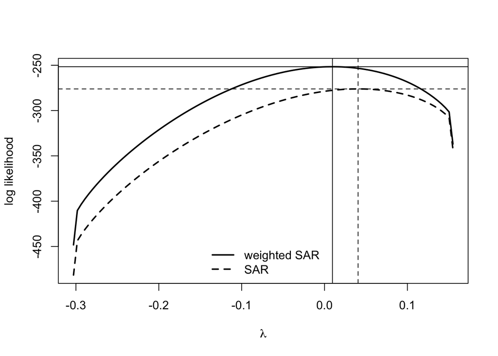

```r
nysar_ll<-spautolm(Z~PEXPOSURE+PCTAGE65P+PCTOWNHOME, data=NY8, family="SAR",
                   listw=NYlistw, llprof=100)
nysarw_ll<-spautolm(Z~PEXPOSURE+PCTAGE65P+PCTOWNHOME, data=NY8, family="SAR",
                    listw=NYlistw, weights=POP8, llprof=100)
ylim <- range(c(nysarw_ll$llprof$ll, nysar_ll$llprof$ll), na.rm=TRUE)
plot(nysarw_ll$llprof$lambda, nysarw_ll$llprof$ll, type="l", xlab=expression(lambda), ylab="log likelihood", ylim=ylim, lwd=2)
abline(v=nysarw_ll$lambda)
abline(h=nysarw_ll$LL)
lines(nysar_ll$llprof$lambda, nysar_ll$llprof$ll, lty=2, lwd=2)
abline(v=nysar_ll$lambda, lty=2)
abline(h=nysar_ll$LL, lty=2)
legend("bottom", legend=c("weighted SAR", "SAR"), lty=c(1,2), lwd=2, bty="n")
```

```r
# Otra opción: SMA
nysmaw<-spautolm(Z~PEXPOSURE+PCTAGE65P+PCTOWNHOME, data=NY8, family="SMA",
                 listw=NYlistw, weights=POP8)
summary(nysmaw)
```

```
##
## Call: spautolm(formula = Z ~ PEXPOSURE + PCTAGE65P + PCTOWNHOME, data = NY8,
##     listw = NYlistw, weights = POP8, family = "SMA")
##
## Residuals:
##       Min        1Q    Median        3Q       Max
## -1.487080 -0.268990  0.093956  0.466055  4.284087
##
## Coefficients:
##              Estimate Std. Error z value  Pr(>|z|)
## (Intercept) -0.795243   0.143749 -5.5321 3.163e-08
## PEXPOSURE    0.080153   0.028237  2.8386  0.004531
## PCTAGE65P    3.820316   0.575463  6.6387 3.165e-11
## PCTOWNHOME  -0.382529   0.156160 -2.4496  0.014302
##
## Lambda: 0.0091843 LR test value: 0.30771 p-value: 0.57909
## Numerical Hessian standard error of lambda: 0.016571
##
## Log likelihood: -251.6112
## ML residual variance (sigma squared): 1105.3, (sigma: 33.245)
## Number of observations: 281
## Number of parameters estimated: 6
## AIC: 515.22
```

## Modelos espaciales como un caso de Modelos Mixtos:

La especificación de dependencia espacial, se puede hacer utilizando un modelo mixto, en donde el efecto aleatorio puede describir la estructura espacial por medio de una matriz de covariancia. El modelo se puede escribir de la siguiente manera:

$$Y = X \beta + Z \gamma + \epsilon$$

En donde el vector $\gamma$ representa los efectos aleatorios y $Z$ se construye con la estructura de la relación espacial. Por ejemplo, $Z$ puede definirse para que represente la misma forma de los modelos CAR y SAR, pero en este caso $Z$ también depende de otro parámetro $\lambda$ que debe ser ajustado. Esta manera de escribir los modelos clásicos es muy útil para traducirla a modelos Bayesianos, debido a que utilizan la misma forma base.

En el lado clásico de la estadística, podemos utilizar las técnicas de máximo verosímil y de ML restringido que ofrece el paquete nlme, en el cual se deja abierta la especificación de la estructura de $\Sigma_{\gamma}$. Note que este caso también puede ser útil para geoestadística. Lo único dificil en este caso es construir las matrices de diseño para cada modelo.

## Modelos GAM, GEE, GLM

Otras maneras de ajustar modelos: ¿qué pasa si comparamos un modelo GAM (aditivo) con el modelo lineal con pesos que ajustamos antes?

```r
NY8$x<-coordinates(NY8)[,1]/1000
NY8$y<-coordinates(NY8)[,2]/1000
nyGAM1 <- gam(Z~PEXPOSURE+PCTAGE65P+PCTOWNHOME+s(x,y), weights=POP8, data=NY8)
anova(nylmw, nyGAM1, test="Chisq")
```

```
## Analysis of Variance Table
##
## Model 1: Z ~ PEXPOSURE + PCTAGE65P + PCTOWNHOME
## Model 2: Z ~ PEXPOSURE + PCTAGE65P + PCTOWNHOME + s(x, y)
##   Res.Df    RSS     Df Sum of Sq Pr(>Chi)
## 1 277.00 310778
## 2 273.19 305229 3.8096    5549.7   0.2671
```

En este caso, $s(x,y)$ se refiere a un término en la regresión que construya un “isotropic thin plate” a partir de las coordendas x y y. Así, un término extra además de las covariables dará un efecto suavizado (con ajuste no paramétrico) a la superficie. En este caso, parece que el término no es importante (no hay evidencia de una diferencia entre modelos), pero podría ser útil para otros casos.

Otra opción en este caso sería utilizar GLM para modelar los casos de leucemia:

```r
NY8 <- readOGR("data/NY8_utm18.shp", "NY8_utm18")
nylam1 <- c(summary(nyGAM1)$edf)
nyGLMp <- glm(as.integer(Cases)~PEXPOSURE+PCTAGE65P+PCTOWNHOME+offset(log(POP8)), data=NY8, family="poisson")
summary(nyGLMp)
```

```
##
## Call:
## glm(formula = as.integer(Cases) ~ PEXPOSURE + PCTAGE65P + PCTOWNHOME +
##     offset(log(POP8)), family = "poisson", data = NY8)
##
## Deviance Residuals:
##     Min       1Q   Median       3Q      Max
## -2.8443  -1.1795  -0.2691   0.6947   3.3094
##
## Coefficients:
##             Estimate Std. Error z value Pr(>|z|)
## (Intercept) -8.22863    0.18900 -43.537  < 2e-16 ***
## PEXPOSURE    0.15866    0.03213   4.938 7.88e-07 ***
## PCTAGE65P    4.19281    0.61243   6.846 7.58e-12 ***
## PCTOWNHOME  -0.40200    0.19649  -2.046   0.0408 *
## ---
## Signif. codes:  0 '***' 0.001 '**' 0.01 '*' 0.05 '.' 0.1 ' ' 1
##
## (Dispersion parameter for poisson family taken to be 1)
##
##     Null deviance: 478.01  on 280  degrees of freedom
## Residual deviance: 398.35  on 277  degrees of freedom
## AIC: 957.37
##
## Number of Fisher Scoring iterations: 5
```

Veamos los residuales en este caso:

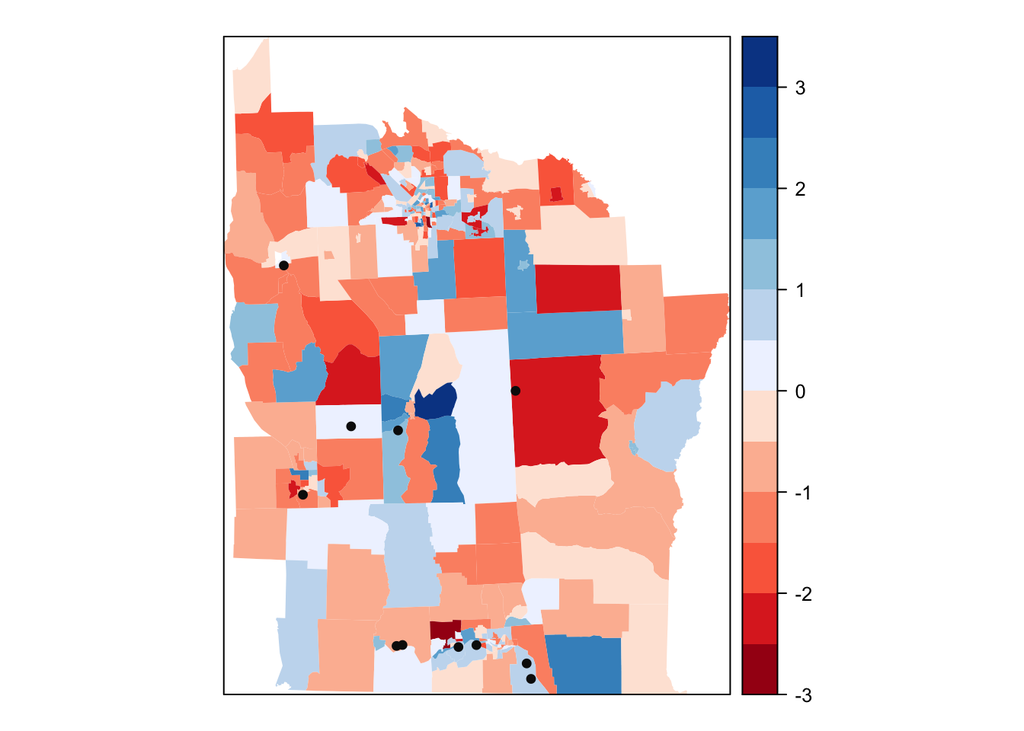

```r
NY8$lmpresid <- residuals(nyGLMp, type="deviance")
gry <- c(rev(brewer.pal(6, "Reds")), brewer.pal(7, "Blues"))
TCEpts <- list("sp.points", TCE, pch=16, col="grey5")
spplot(NY8, "lmpresid", sp.layout=list(TCEpts), col.regions=gry, col="transparent", lwd=0.5, at=seq(-3,3.5,0.5))
```

¿Existe una autocorrelación espacial?

```r
NY8$lmpresid <- residuals(nyGLMp, type="deviance")
lm.morantest(nyGLMp, listw=NYlistwW)
```

```
##
##  Global Moran I for regression residuals
##
## data:
## model: glm(formula = as.integer(Cases) ~ PEXPOSURE + PCTAGE65P +
## PCTOWNHOME + offset(log(POP8)), family = "poisson", data = NY8)
## weights: NYlistwW
##
## Moran I statistic standard deviate = 0.92441, p-value = 0.1776
## alternative hypothesis: greater
## sample estimates:
## Observed Moran I      Expectation         Variance
##      0.030237136     -0.004802292      0.001436757
```

Parece que no hay una autocorrelación espacial.

Ahora, podemos ampliar el ejercicio adicionando un término no paramétrico:

```r
NY8$x<-coordinates(NY8)[,1]/1000
NY8$y<-coordinates(NY8)[,2]/1000
nyGAMp <- gam(as.integer(Cases)~PEXPOSURE+PCTAGE65P+PCTOWNHOME+offset(log(POP8))+s(x,y), data=NY8, family="poisson")
summary(nyGAMp)
```

```
##
## Family: poisson
## Link function: log
##
## Formula:
## as.integer(Cases) ~ PEXPOSURE + PCTAGE65P + PCTOWNHOME + offset(log(POP8)) +
##     s(x, y)
##
## Parametric coefficients:
##             Estimate Std. Error z value Pr(>|z|)
## (Intercept) -8.27472    0.22332 -37.054  < 2e-16 ***
## PEXPOSURE    0.19446    0.06317   3.078  0.00208 **
## PCTAGE65P    3.84576    0.65996   5.827 5.64e-09 ***
## PCTOWNHOME  -0.36459    0.20543  -1.775  0.07594 .
## ---
## Signif. codes:  0 '***' 0.001 '**' 0.01 '*' 0.05 '.' 0.1 ' ' 1
##
## Approximate significance of smooth terms:
##          edf Ref.df Chi.sq p-value
## s(x,y) 8.357  11.58   13.1   0.316
##
## R-sq.(adj) =  0.373   Deviance explained =   21%
## UBRE = 0.43135  Scale est. = 1         n = 281
```

```r
anova(nyGLMp, nyGAMp, test="Chisq")
```

```
## Analysis of Deviance Table
##
## Model 1: as.integer(Cases) ~ PEXPOSURE + PCTAGE65P + PCTOWNHOME + offset(log(POP8))
## Model 2: as.integer(Cases) ~ PEXPOSURE + PCTAGE65P + PCTOWNHOME + offset(log(POP8)) +
##     s(x, y)
##   Resid. Df Resid. Dev     Df Deviance Pr(>Chi)
## 1    277.00     398.35
## 2    268.64     377.49 8.3573   20.855 0.009309 **
## ---
## Signif. codes:  0 '***' 0.001 '**' 0.01 '*' 0.05 '.' 0.1 ' ' 1
```

```r
nylam1 <- c(summary(nyGAMp)$edf)
```